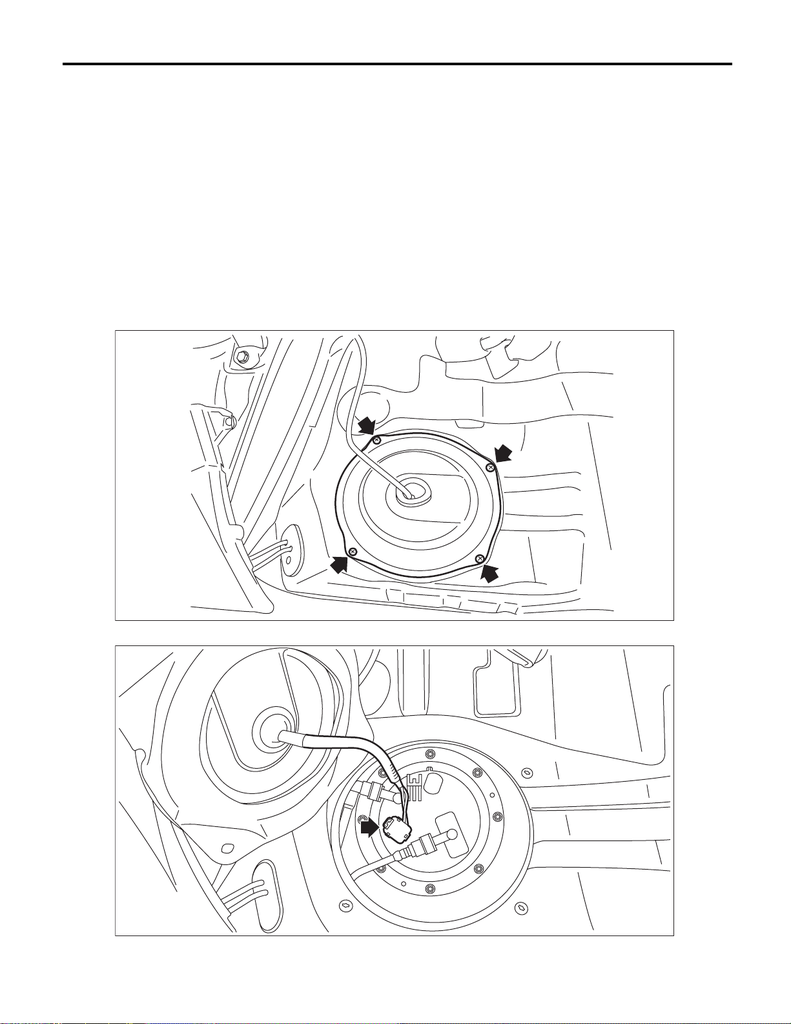

FU(w/o STI)-152

Fuel Tank

FUEL INJECTION (FUEL SYSTEMS)

34.Fuel Tank

A: REMOVAL

WARNING:

Place “NO OPEN FLAMES” signs near the working area.

CAUTION:

• Be careful not to spill fuel.

• Catch the fuel from the tubes using a container or cloth.

1) Release the fuel pressure. <Ref. to FU(w/o STI)-146, RELEASING OF FUEL PRESSURE, PROCE-

DURE, Fuel.>

2) Drain fuel. <Ref. to FU(w/o STI)-146, DRAINING FUEL (WITH SUBARU SELECT MONITOR), PROCE-

DURE, Fuel.>

3) Disconnect the ground terminal from battery sensor. <Ref. to NT-5, BATTERY, NOTE, Note.>

4) Remove the rear seat cushion. <Ref. to SE-29, REMOVAL, Rear Seat.>

5) Remove the service hole cover of fuel pump.

6) Disconnect connectors from the fuel pump, and move aside the service hole cover.

FU-06417

FU-07694

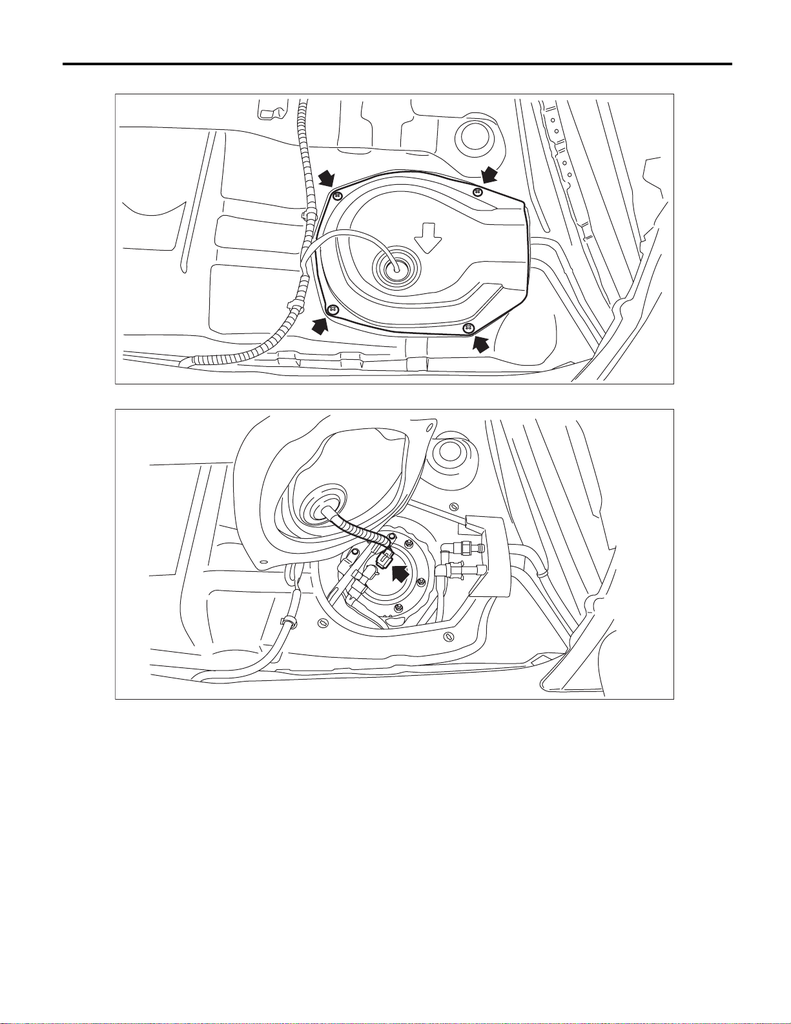

FU(w/o STI)-153

Fuel Tank

FUEL INJECTION (FUEL SYSTEMS)

7) Remove the service hole cover of fuel sub level sensor.

8) Disconnect the connector from the fuel sub level sensor, and move aside the service hole cover.

FU-06419

FU-06420

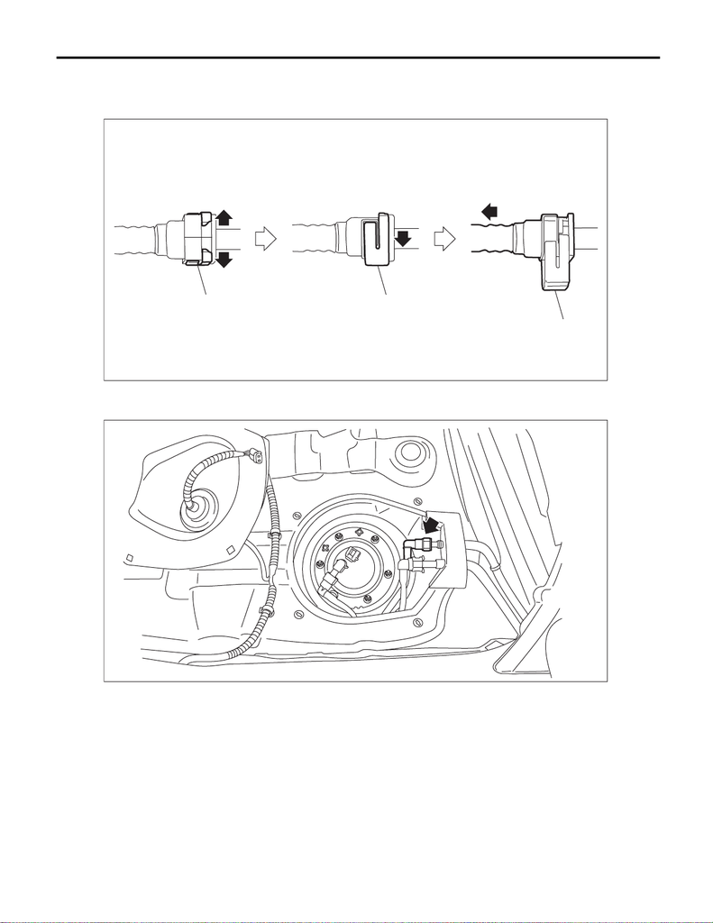

FU(w/o STI)-154

Fuel Tank

FUEL INJECTION (FUEL SYSTEMS)

9) Disconnect the quick connector on the fuel delivery tube.

NOTE:

Disconnect the quick connector as shown in the figure.

10) Lift up the vehicle.

11) Remove the rear exhaust pipe. <Ref. to EX(w/o STI)-50, REMOVAL, Rear Exhaust Pipe.>

12) Remove the rear differential. <Ref. to DI-19, REMOVAL, Rear Differential (T-type).>

(a) Slider

EC-02771

(a)

(a)

(a)

FU-06421

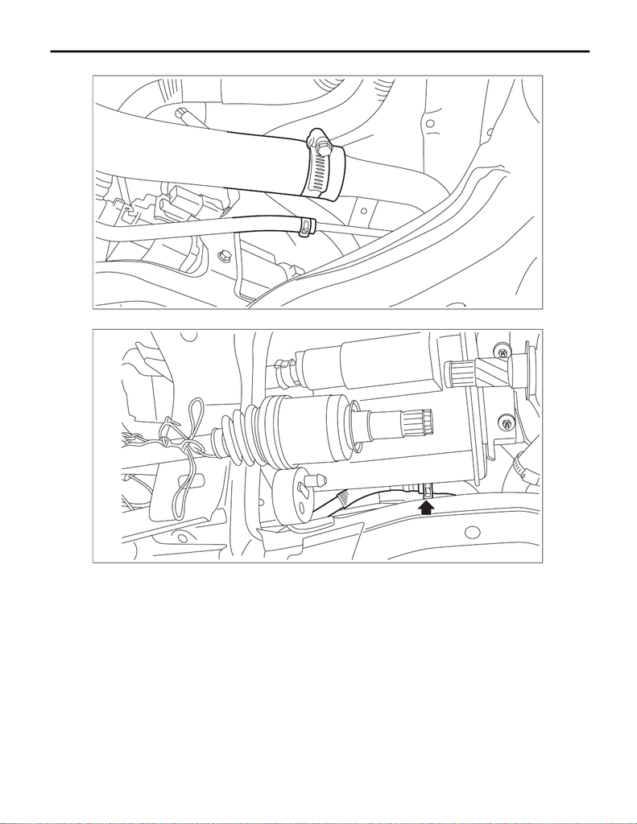

FU(w/o STI)-155

Fuel Tank

FUEL INJECTION (FUEL SYSTEMS)

13) Disconnect the fuel filler hose (A) and evaporation hose (B) from the fuel filler pipe assembly.

14) Disconnect the vent tube from vent hose.

15) Remove the fuel tank protector. <Ref. to FU(w/o STI)-151, REMOVAL, Fuel Tank Protector.>

FU-08281

(A)

(B)

FU-08208

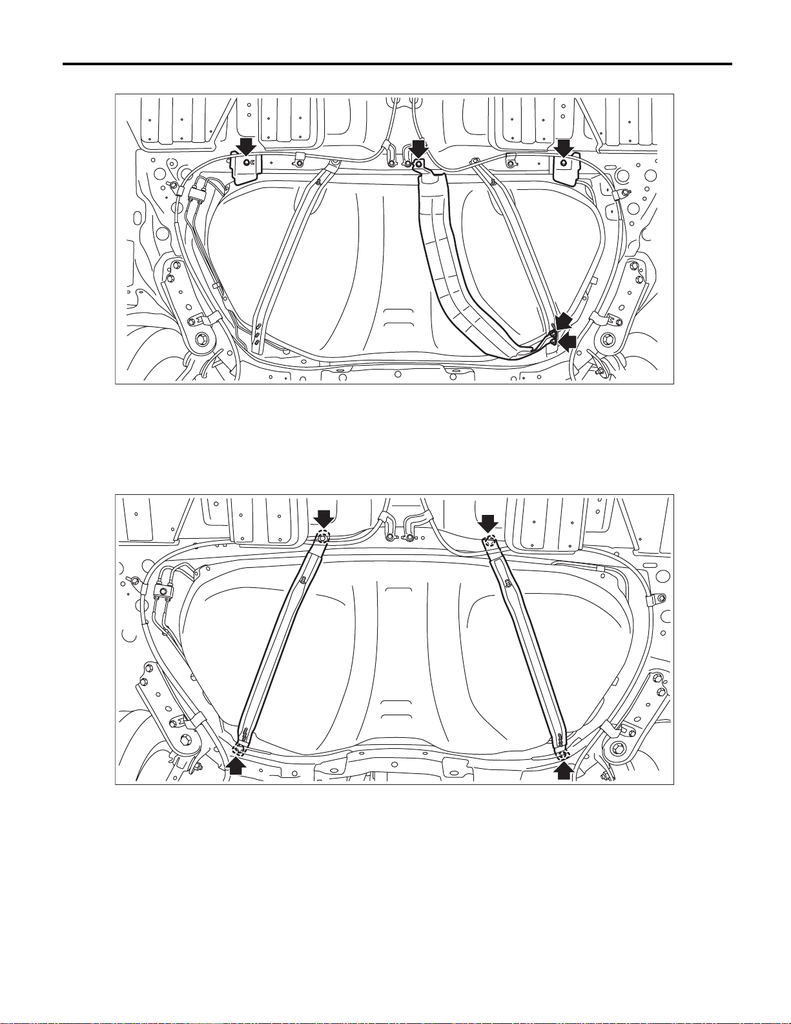

FU(w/o STI)-156

Fuel Tank

FUEL INJECTION (FUEL SYSTEMS)

16) Remove the heat shield cover and stopper.

17) Support the fuel tank with a transmission jack, remove the bolts from the fuel tank band, and remove the

fuel tank from the vehicle.

WARNING:

• A helper is required to perform this work.

• Fuel may remain in the fuel tank. This will cause the left and right sides to be unbalanced. Be care-

ful not to drop the fuel tank.

FU-08282

FU-08283

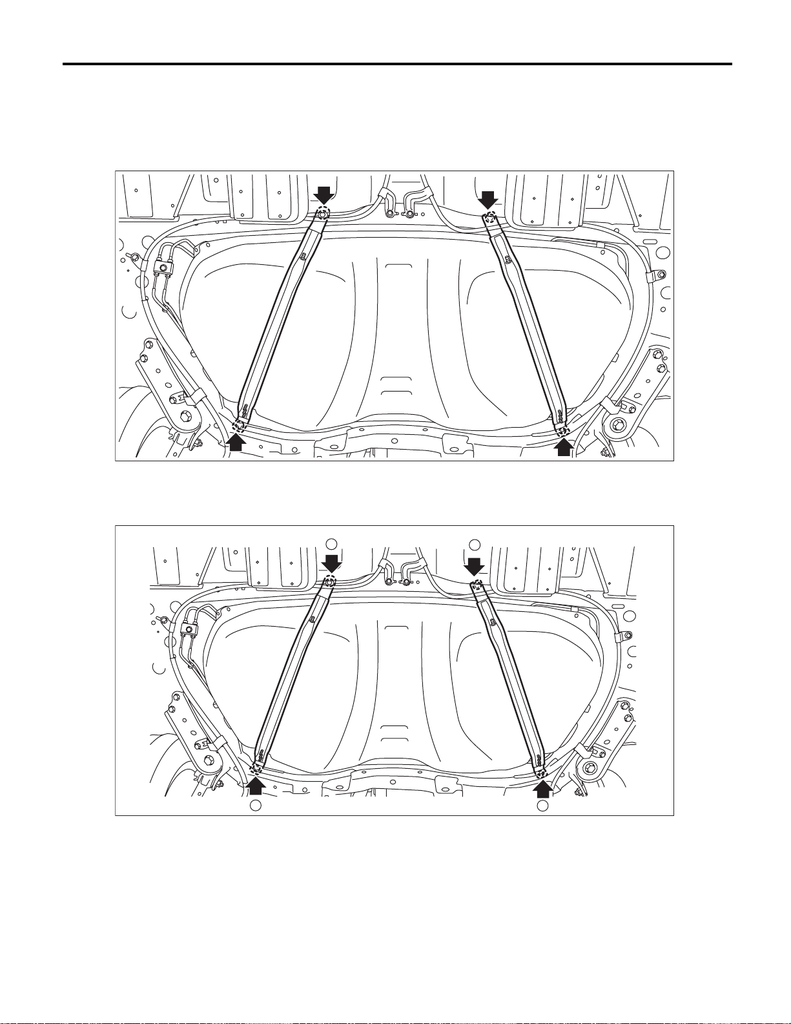

FU(w/o STI)-157

Fuel Tank

FUEL INJECTION (FUEL SYSTEMS)

B: INSTALLATION

1) Support the fuel tank with a transmission jack, set the fuel tank in place, and temporarily tighten the bolts

of the fuel tank band.

WARNING:

A helper is required to perform this work.

2) Tighten the bolts of the fuel tank band in the order shown in the figure.

Tightening torque:

33 N·m (3.4 kgf-m, 24.3 ft-lb)

FU-08283

FU-08323

1

2

3

4

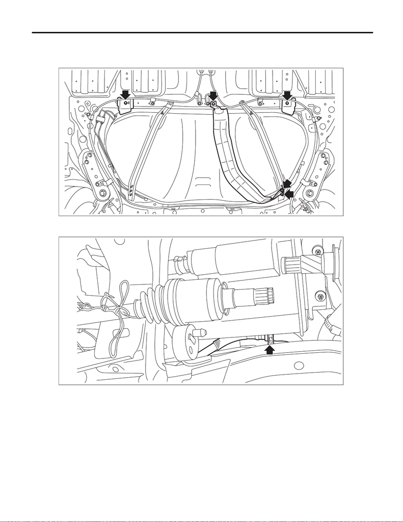

FU(w/o STI)-158

Fuel Tank

FUEL INJECTION (FUEL SYSTEMS)

3) Install the heat shield cover and stopper.

Tightening torque:

18 N·m (1.8 kgf-m, 13.3 ft-lb)

4) Install the fuel tank protector. <Ref. to FU(w/o STI)-151, INSTALLATION, Fuel Tank Protector.>

5) Connect the vent tube to the vent hose.

FU-08282

FU-08208

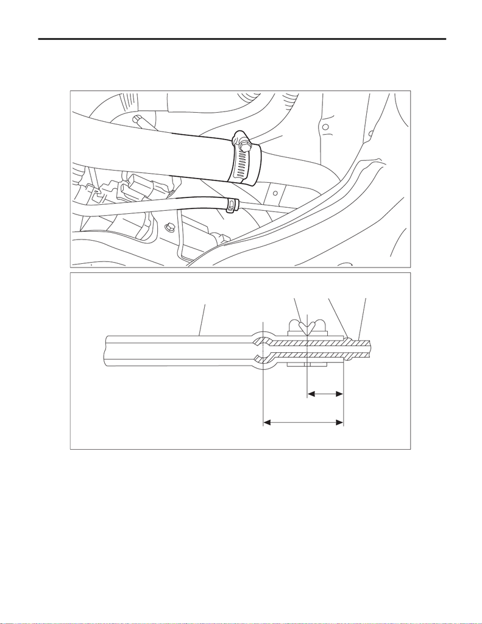

FU(w/o STI)-159

Fuel Tank

FUEL INJECTION (FUEL SYSTEMS)

6) Securely insert the fuel filler hose (A) and evaporation hose (B) until the hose end contacts the spool, then

attach the clamp or clip as shown in the figure.

Tightening torque:

2.5 N·m (0.3 kgf-m, 1.8 ft-lb)

7) Install the rear differential. <Ref. to DI-21, INSTALLATION, Rear Differential (T-type).>

8) Install the rear exhaust pipe. <Ref. to EX(w/o STI)-51, INSTALLATION, Rear Exhaust Pipe.>

(1) Hose (3) Spool (4) Pipe

(2) Clamp or clip

FU-08281

(A)

(B)

L

L/2

(1)

(2)

(3)

(4)

FU-06185

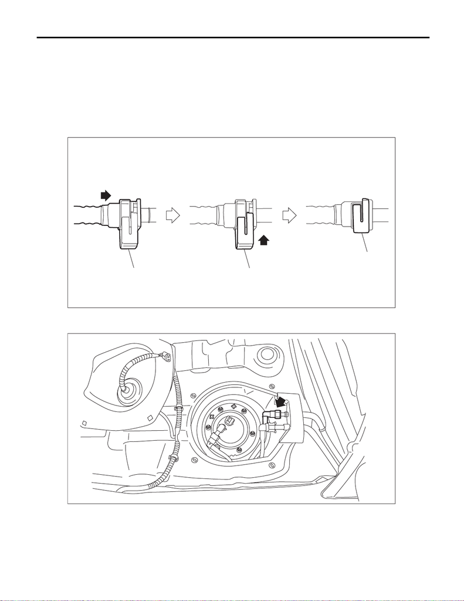

FU(w/o STI)-160

Fuel Tank

FUEL INJECTION (FUEL SYSTEMS)

9) Connect the quick connector of the fuel delivery tube.

CAUTION:

• Check that there is no damage or dust on the quick connector. If necessary, clean the seal surface

of the pipe.

• When connecting the quick connector, make sure to insert it all the way in before locking the slider.

• When it is difficult to lock the slider, check that the connector is fully inserted.

• After locking the slider, check again that the quick connector is securely connected.

NOTE:

Connect the quick connector as shown in the figure.

(a) Slider

EC-02779

(a)

(a)

(a)

FU-06421

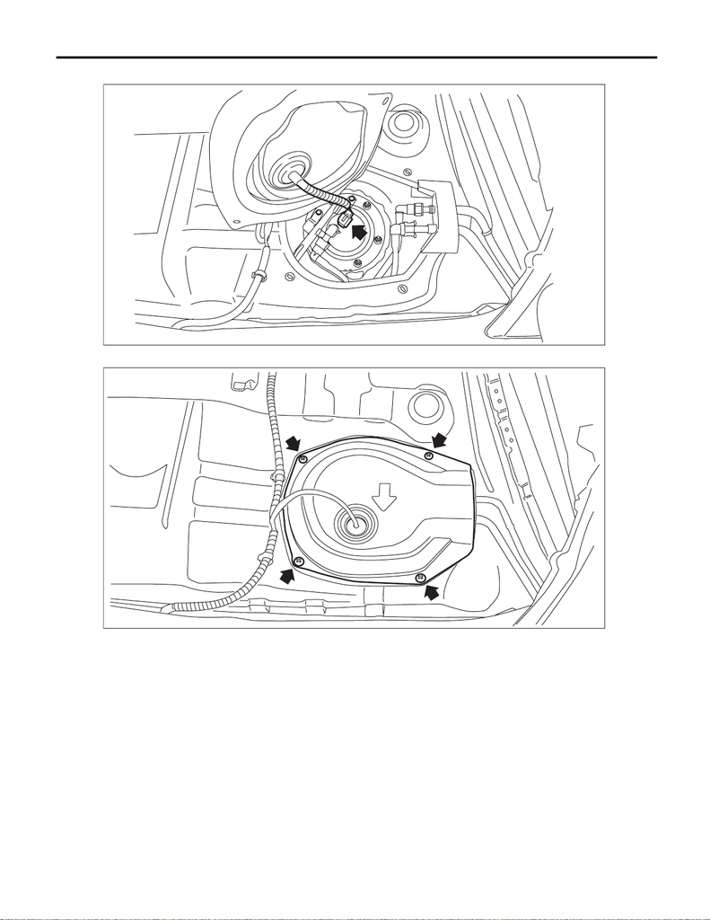

FU(w/o STI)-161

Fuel Tank

FUEL INJECTION (FUEL SYSTEMS)

10) Connect the connector to the fuel sub level sensor.

11) Install the service hole cover of fuel sub level sensor.

FU-06420

FU-06419

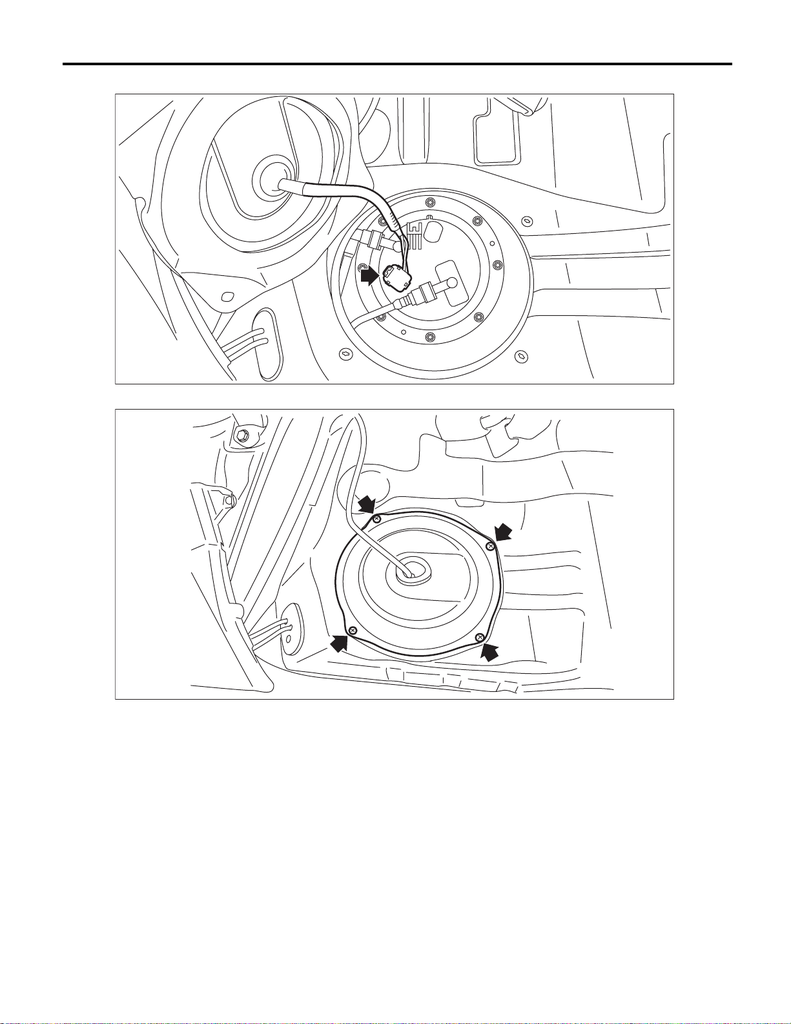

FU(w/o STI)-162

Fuel Tank

FUEL INJECTION (FUEL SYSTEMS)

12) Connect the connector to the fuel pump.

13) Install the service hole cover of fuel pump.

14) Install the rear seat cushion. <Ref. to SE-33, INSTALLATION, Rear Seat.>

15) Connect the ground terminal to battery sensor. <Ref. to NT-5, BATTERY, NOTE, Note.>

C: INSPECTION

1) Check that the fuel tank and fuel pipe have no deformation, cracks and other damages.

2) Check that the fuel hose and tube have no cracks, damage or loose part.

FU-07694

FU-06417